# INSTALLING DEPENDENCIES

> SEX

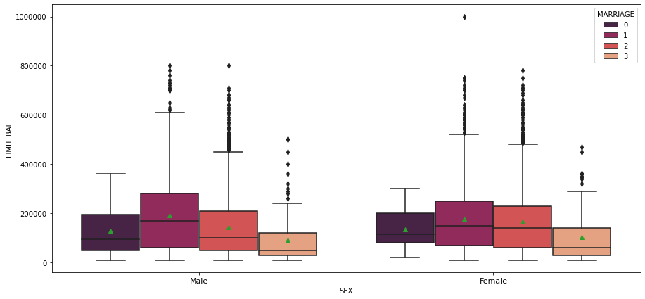

```python
plt.figure(figsize=(15,7))

sns.boxplot(hue = "MARRIAGE", y = "LIMIT_BAL", x = 'SEX', data = df, palette = 'rocket', showmeans=True)

plt.ticklabel_format(style='plain', axis='y') #repressing scientific notation
plt.xticks([0,1],['Male','Female'], fontsize = 11)

plt.show()
```

> EDUCATION

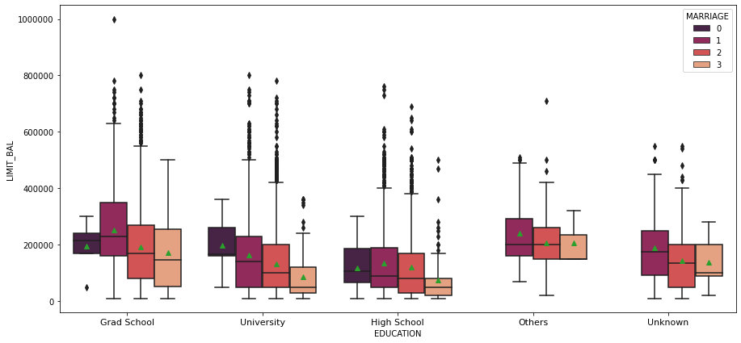

```python
plt.figure(figsize=(15,7))

sns.boxplot(x = "EDUCATION", y = "LIMIT_BAL", hue = 'MARRIAGE', data = df, palette = 'rocket', showmeans=True)

plt.ticklabel_format(style='plain', axis='y') #repressing scientific notation
plt.xticks([0,1,2,3,4],['Grad School','University','High School','Others','Unknown'], fontsize = 11)

plt.show()
```

> AGE GROUP

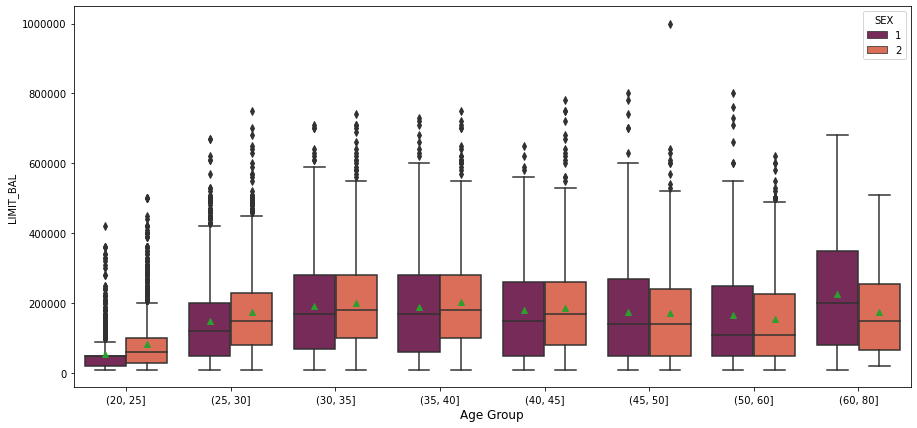

```python
plt.figure(figsize=(15,7))

sns.boxplot(x = "AgeBin", y = "LIMIT_BAL", hue = 'SEX', data = df, palette = 'rocket', order = AgeBin_order, showmeans=True)

plt.ticklabel_format(style='plain', axis='y') #repressing scientific notation
plt.xlabel("Age Group", fontsize= 12)

plt.show()
```

> ATTRIBUTE DEPENDENCY W.R.T AGE GROUPS FOR LIMIT_BAL

> SEX

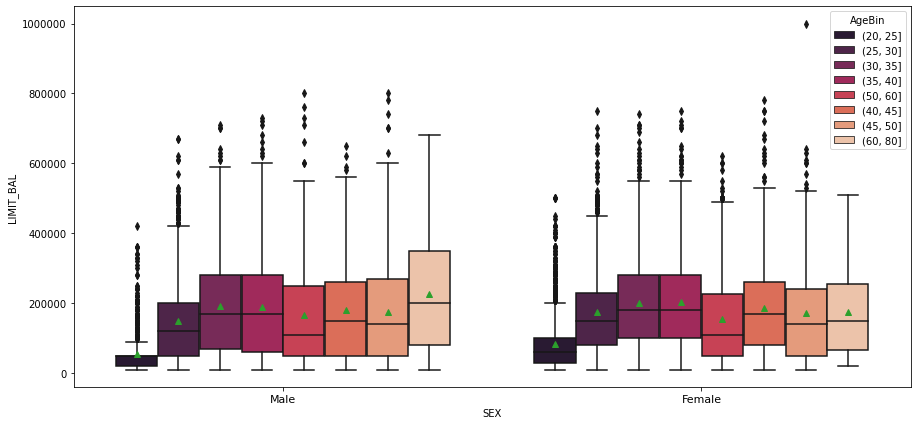

```python
plt.figure(figsize=(15,7))

sns.boxplot(hue = "AgeBin", y = "LIMIT_BAL", x = 'SEX', data = df, palette = 'rocket', showmeans=True)

plt.ticklabel_format(style='plain', axis='y') #repressing scientific notation
plt.xticks([0,1],['Male','Female'], fontsize = 11)

plt.show()
```

> EDUCATION

[figure not shown]

```python
plt.figure(figsize=(15,7))

sns.boxplot(x = "EDUCATION", y = "LIMIT_BAL", hue = 'MARRIAGE', data = df, palette = 'rocket', showmeans=True)

plt.ticklabel_format(style='plain', axis='y') #repressing scientific notation
plt.xticks([0,1,2,3,4],['Grad School','University','High School','Others','Unknown'], fontsize = 11)

plt.show()
```

> MARITIAL STATUS

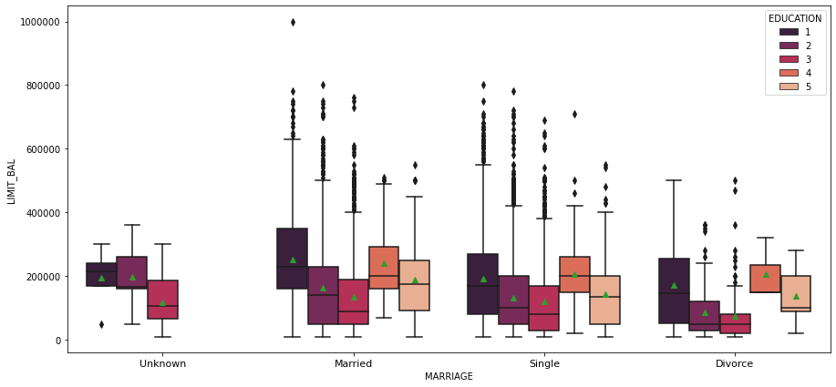

```python
plt.figure(figsize=(15,7))

sns.boxplot(x = "MARRIAGE", y = "LIMIT_BAL", hue = 'EDUCATION', data = df, palette = 'rocket', showmeans=True)

plt.ticklabel_format(style='plain', axis='y') #repressing scientific notation
plt.xticks([0,1,2,3],['Unknown', 'Married', 'Single', 'Divorce'], fontsize = 11)

plt.show()
```

PAY_X

> PMF

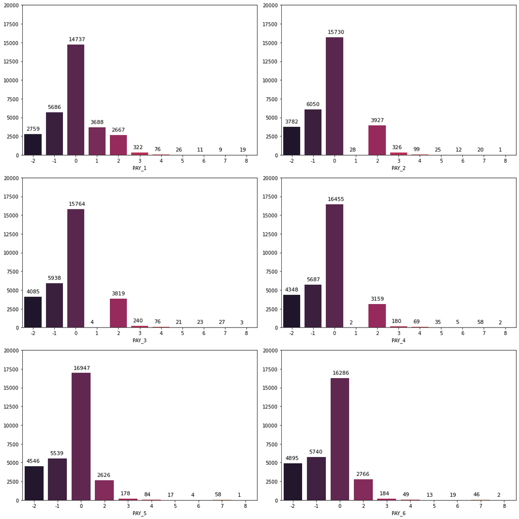

```python
pay_x_feat = ['PAY_1', 'PAY_2', 'PAY_3', 'PAY_4', 'PAY_5', 'PAY_6']
plt.figure(figsize=(15,15))

for i,col in enumerate(pay_x_feat):
    plt.subplot(3,2,i + 1)
    ax = sns.countplot(df.loc[:,col], palette = 'rocket')
    plt.ylim(0,20000)
    plt.ylabel('')
    plt.tight_layout()

    for p in ax.patches:
        ax.annotate((p.get_height()), (p.get_x()+0.08, p.get_height()+500), fontsize = 11)

plt.show()
```

> From Plots we can conclude that most of the users pays Amount back before 4 months delay

> PDF

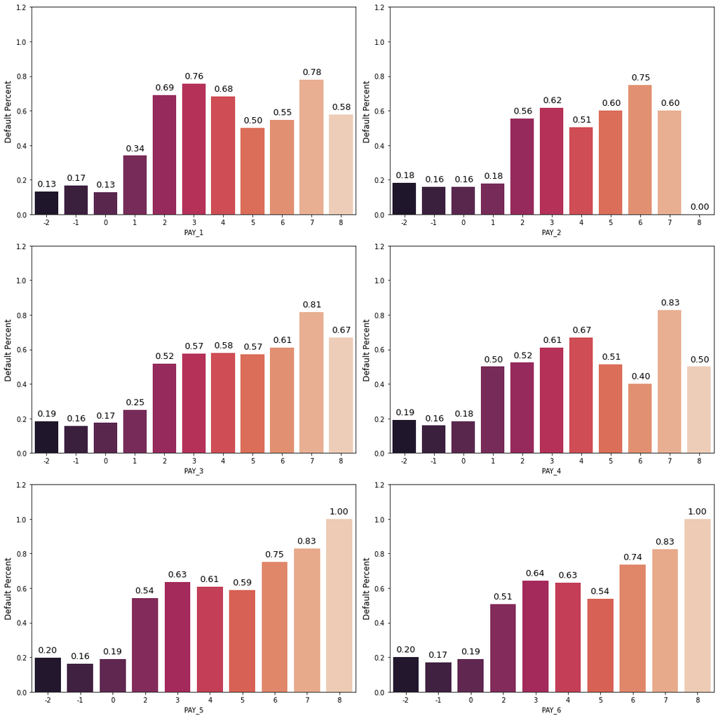

```python
plt.figure(figsize=(15,15))

for i,col in enumerate(pay_x_feat):
    plt.subplot(3,2,i + 1)
    ax = sns.barplot(x = col, y = "Default", data = df, palette = 'rocket', ci = None)
    plt.ylabel("Default Percent", fontsize= 12)
    plt.ylim(0,1.2)
    plt.tight_layout()

    for p in ax.patches:
        ax.annotate("%.2f" %(p.get_height()), (p.get_x()+0.09, p.get_height()+0.03),fontsize=13)

plt.show()
```

> LETS MERGE LABELS WITH 4,5,67...

```python
df['PAY_1_new'] = df['PAY_1'].copy()
df['PAY_2_new'] = df['PAY_2'].copy()
df['PAY_3_new'] = df['PAY_3'].copy()
df['PAY_4_new'] = df['PAY_4'].copy()
df['PAY_5_new'] = df['PAY_5'].copy()
df['PAY_6_new'] = df['PAY_6'].copy()
```

```python
pay_x_new = ['PAY_1_new', 'PAY_2_new', 'PAY_3_new', 'PAY_4_new', 'PAY_5_new', 'PAY_6_new']

for col in pay_x_new:
    df.loc[:,col] = df.loc[:,col].replace(5,4)
    df.loc[:,col] = df.loc[:,col].replace(6,4)
    df.loc[:,col] = df.loc[:,col].replace(7,4)
    df.loc[:,col] = df.loc[:,col].replace(8,4)
```

> PLOTTING MODIFIED PAY_X FEATURES

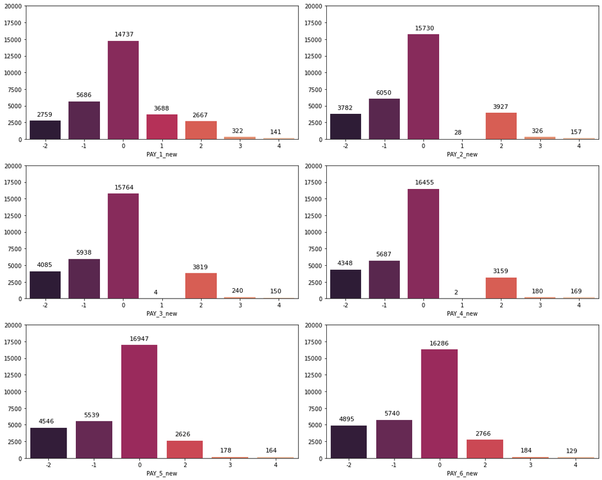

```python
plt.figure(figsize=(15,12))

for i,col in enumerate(pay_x_new):
    plt.subplot(3,2,i + 1)
    ax = sns.countplot(data = df, x = col, palette = 'rocket')
    plt.ylim(0,20000)
    plt.ylabel('')
    plt.tight_layout()

    for p in ax.patches:
        ax.annotate((p.get_height()), (p.get_x()+0.180, p.get_height()+700), fontsize = 11)

plt.show()
```

> PROBABILITY FOR DEFAULT POSITIVE

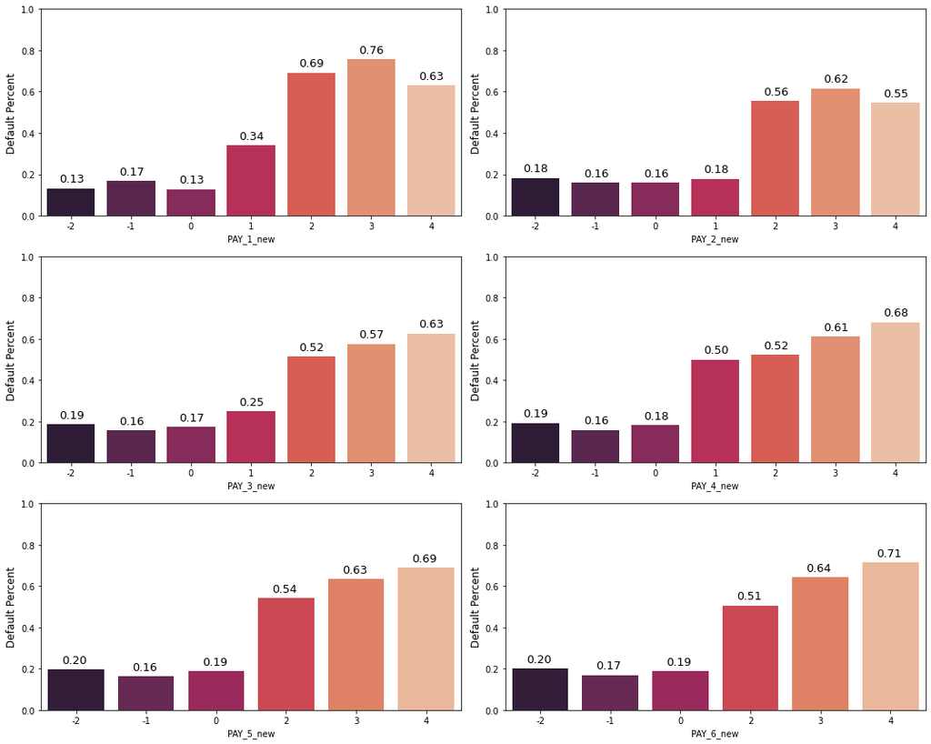

```python
plt.figure(figsize=(15,12))

for i,col in enumerate(pay_x_new):
    plt.subplot(3,2,i + 1)
    ax = sns.barplot(x = col, y = "Default", data = df, palette = 'rocket', ci = None)
    plt.ylabel("Default Percent", fontsize= 12)
    plt.ylim(0,1.0)
    plt.tight_layout()

    for p in ax.patches:
        ax.annotate("%.2f" %(p.get_height()), (p.get_x()+0.2, p.get_height()+0.03),fontsize=13)

plt.show()
```

> BILL_AMTX

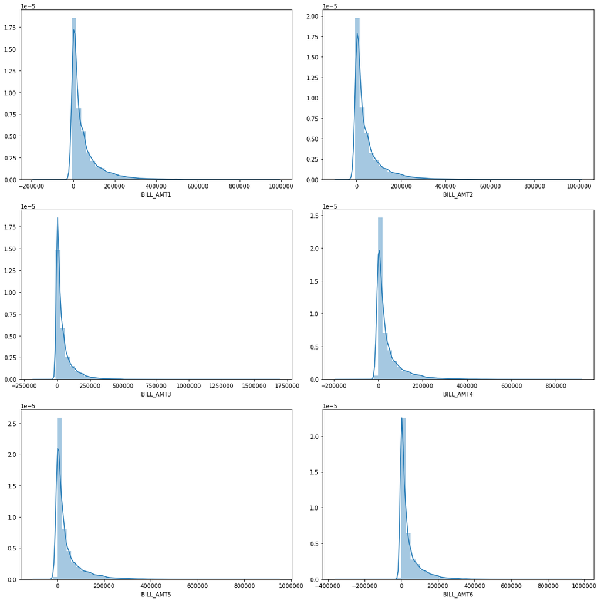

```python
bill_amtx_feat = ['BILL_AMT1', 'BILL_AMT2', 'BILL_AMT3', 'BILL_AMT4', 'BILL_AMT5', 'BILL_AMT6']
plt.figure(figsize=(15,15))

for i,col in enumerate(bill_amtx_feat):
    plt.subplot(3,2,i + 1)
    sns.distplot(df.loc[:,col])
    plt.ticklabel_format(style='plain', axis='x') #repressing scientific notation
    plt.ylabel('')
    plt.tight_layout()

plt.show()
```

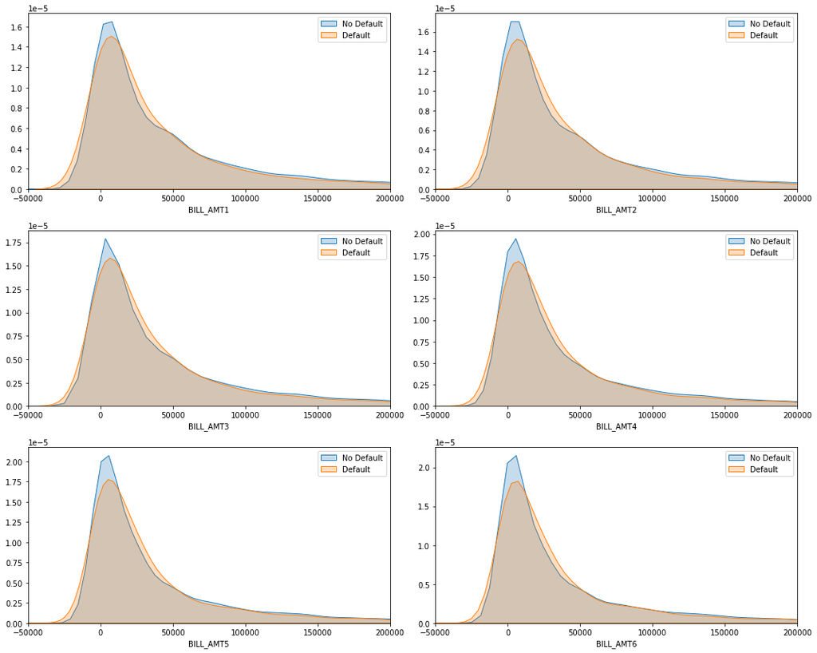

```python
plt.figure(figsize=(15,12))

for i,col in enumerate(bill_amtx_feat):
    plt.subplot(3,2,i + 1)
    sns.kdeplot(df.loc[(df['Default'] == 0), col], label = 'No Default', shade = True)
    sns.kdeplot(df.loc[(df['Default'] == 1), col], label = 'Default', shade = True)
    plt.xlim(-50000,200000)
    plt.ylabel('')
    plt.legend()
    plt.tight_layout()

plt.show()
```

```python
df['BILL_AMT1_new'] = df['BILL_AMT1'].copy()
df['BILL_AMT2_new'] = df['BILL_AMT2'].copy()
df['BILL_AMT3_new'] = df['BILL_AMT3'].copy()
df['BILL_AMT4_new'] = df['BILL_AMT4'].copy()
df['BILL_AMT5_new'] = df['BILL_AMT5'].copy()
df['BILL_AMT6_new'] = df['BILL_AMT6'].copy()
```

> CHECKING DATA DISTRIBUTIION OVER BILL_AMT SPAN

```python
bill_amtx_feat_new = ['BILL_AMT1_new', 'BILL_AMT2_new', 'BILL_AMT3_new', 'BILL_AMT4_new', 'BILL_AMT5_new', 'BILL_AMT6_new']

for i, col in enumerate (bill_amtx_feat_new):
    df[col] = pd.cut(df[bill_amtx_feat[i]],[-400000,-1,0,25000, 70000, 90000, 200000, 2000000])
    print(df[col].value_counts())
```

```
(0, 25000]           12965
(25000, 70000]        7226
(90000, 200000]       4017
(-1, 0]               2008
(70000, 90000]        1671
(200000, 2000000]     1523
(-400000, -1]          590
Name: BILL_AMT1_new, dtype: int64
(0, 25000]           12647
(25000, 70000]        7272
(90000, 200000]       3911
(-1, 0]               2506
(70000, 90000]        1603
(200000, 2000000]     1392
(-400000, -1]          669
Name: BILL_AMT2_new, dtype: int64
(0, 25000]           12696
(25000, 70000]        7198
(90000, 200000]       3750
(-1, 0]               2870
(70000, 90000]        1575
(200000, 2000000]     1256
(-400000, -1]          655
Name: BILL_AMT3_new, dtype: int64
(0, 25000]           13081
(25000, 70000]        6983
(90000, 200000]       3546
(-1, 0]               3195
(70000, 90000]        1495
(200000, 2000000]     1025
(-400000, -1]          675
Name: BILL_AMT4_new, dtype: int64
(0, 25000]           13401
(25000, 70000]        6784
(-1, 0]               3506
(90000, 200000]       3368
(70000, 90000]        1410
(200000, 2000000]      876
(-400000, -1]          655
Name: BILL_AMT5_new, dtype: int64
(0, 25000]           13163
(25000, 70000]        6639
(-1, 0]               4020
(90000, 200000]       3301
(70000, 90000]        1368
(200000, 2000000]      821
(-400000, -1]          688
Name: BILL_AMT6_new, dtype: int64
```

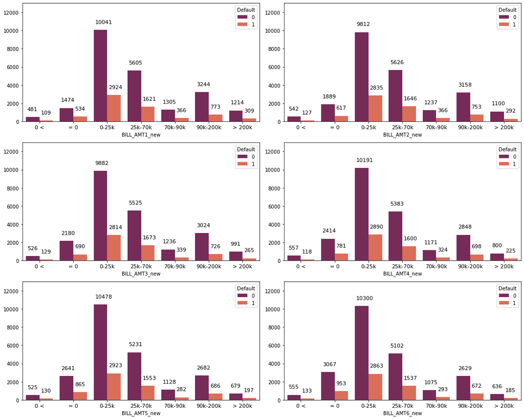

```python
plt.figure(figsize=(15,12))

for i,col in enumerate(bill_amtx_feat_new):
    plt.subplot(3,2,i + 1)
    ax = sns.countplot(data = df, x = col, hue="Default", palette = 'rocket')
    plt.ylim(0,13000)
    plt.ylabel('')
    plt.xticks([0,1,2,3,4,5,6],['0 <', '= 0', '0-25k', '25k-70k', '70k-90k', '90k-200k', '> 200k'], fontsize = 11)
    plt.tight_layout()

    for p in ax.patches:
        ax.annotate((p.get_height()), (p.get_x()+0.04, p.get_height()+700), fontsize = 11)

plt.show()
```

> CHECKING PROBABILITY DISTRIBUTION OVER BILL_AMT

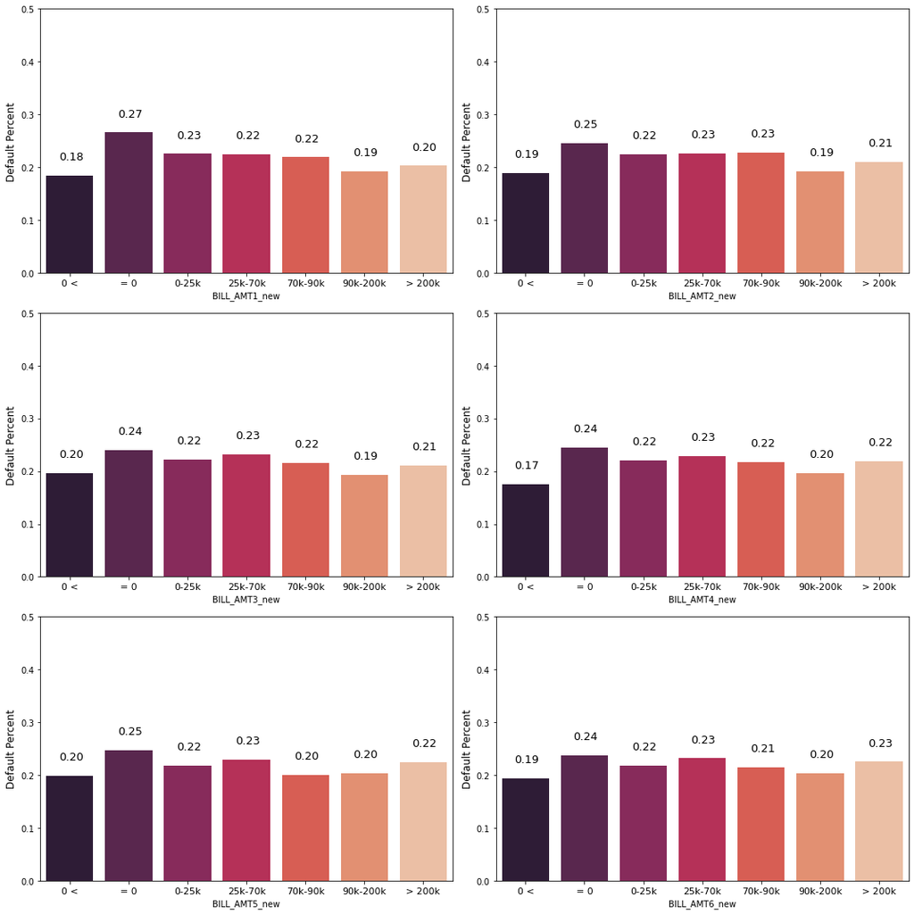

```python
plt.figure(figsize=(15,15))

for i,col in enumerate(bill_amtx_feat_new):
    plt.subplot(3,2,i + 1)
    ax = sns.barplot(x = col, y = "Default", data = df, palette = 'rocket', ci = None)
    plt.ylabel("Default Percent", fontsize= 12)
    plt.ylim(0,0.5)
    plt.xticks([0,1,2,3,4,5,6],['0 <', '= 0', '0-25k', '25k-70k', '70k-90k', '90k-200k', '> 200k'], fontsize = 11)
    plt.tight_layout()

    for p in ax.patches:
        ax.annotate("%.2f" %(p.get_height()), (p.get_x()+0.21, p.get_height()+0.03),fontsize=13)

plt.show()
```

> PREVIOUS PAYMENT - PAY_AMTX

> DATA DISTRIBUTION

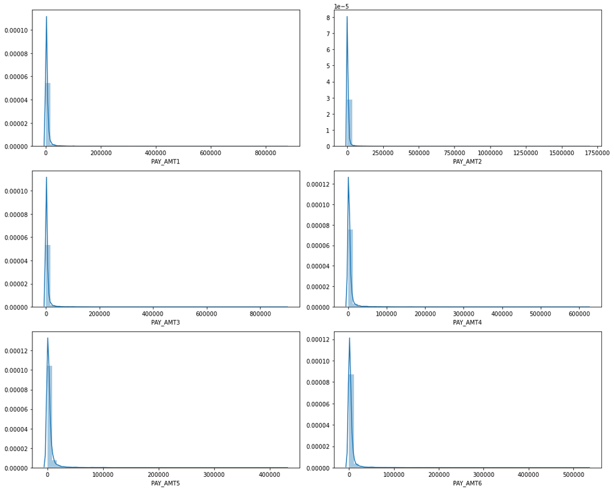

```python
pay_amtx_feat = ['PAY_AMT1', 'PAY_AMT2', 'PAY_AMT3', 'PAY_AMT4', 'PAY_AMT5', 'PAY_AMT6']
plt.figure(figsize=(15,12))

for i,col in enumerate(pay_amtx_feat):
    plt.subplot(3,2,i + 1)
    sns.distplot(df.loc[:,col])
    plt.ticklabel_format(style='plain', axis='x') #repressing scientific notation
    plt.ylabel('')
    plt.tight_layout()

plt.show()
```

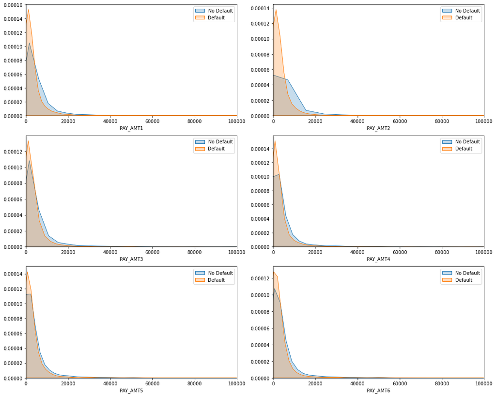

```python
plt.figure(figsize=(15,12))

for i,col in enumerate(pay_amtx_feat):
    plt.subplot(3,2,i + 1)
    sns.kdeplot(df.loc[(df['Default'] == 0), col], label = 'No Default', shade = True)
    sns.kdeplot(df.loc[(df['Default'] == 1), col], label = 'Default', shade = True)
    plt.xlim(0,100000)
    plt.ylabel('')
    plt.legend()
    plt.tight_layout()

plt.show()
```

> CHECKING DATA DISTRIBUTION OVER SPANS

```python
df['PAY_AMT1_new'] = df['PAY_AMT1'].copy()
df['PAY_AMT2_new'] = df['PAY_AMT2'].copy()
df['PAY_AMT3_new'] = df['PAY_AMT3'].copy()
df['PAY_AMT4_new'] = df['PAY_AMT4'].copy()
df['PAY_AMT5_new'] = df['PAY_AMT5'].copy()
df['PAY_AMT6_new'] = df['PAY_AMT6'].copy()
```

```python
pay_amtx_new = ['PAY_AMT1_new', 'PAY_AMT2_new', 'PAY_AMT3_new', 'PAY_AMT4_new', 'PAY_AMT5_new', 'PAY_AMT6_new']

for i, col in enumerate (pay_amtx_new):
    df[col] = pd.cut(df[pay_amtx_feat[i]],[-1, 0, 25000, 50000, 75000, 100000, 2000000])
    print(df[col].value_counts())
```

```
(0, 25000]           23730
(-1, 0]               5249
(25000, 50000]         550
(50000, 75000]         221
(100000, 2000000]      149
(75000, 100000]        101
Name: PAY_AMT1_new, dtype: int64
(0, 25000]           23569
(-1, 0]               5396
(25000, 50000]         556
(100000, 2000000]      196
(50000, 75000]         171
(75000, 100000]        112
Name: PAY_AMT2_new, dtype: int64
(0, 25000]           23068
(-1, 0]               5968
(25000, 50000]         514
(100000, 2000000]      177
(50000, 75000]         173
(75000, 100000]        100
Name: PAY_AMT3_new, dtype: int64
(0, 25000]           22641
(-1, 0]               6408
(25000, 50000]         533
(50000, 75000]         170
(100000, 2000000]      147
(75000, 100000]        101
Name: PAY_AMT4_new, dtype: int64
(0, 25000]           22382
(-1, 0]               6703
(25000, 50000]         493
(50000, 75000]         159
(100000, 2000000]      154
(75000, 100000]        109
Name: PAY_AMT5_new, dtype: int64
(0, 25000]           21785
(-1, 0]               7173
(25000, 50000]         517
(100000, 2000000]      225
(50000, 75000]         194
(75000, 100000]        106
Name: PAY_AMT6_new, dtype: int64
```

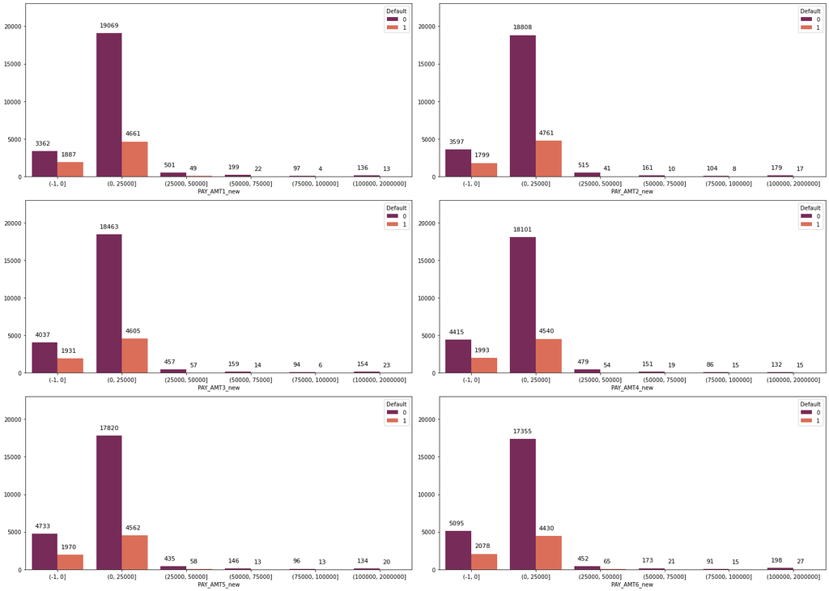

```python
plt.figure(figsize=(21,15))

for i,col in enumerate(pay_amtx_new):
    plt.subplot(3,2,i + 1)
    ax = sns.countplot(data = df, x = col, hue="Default", palette = 'rocket')
    plt.ylim(0,23000)
    plt.ylabel('')
    plt.tight_layout()

    for p in ax.patches:
        ax.annotate((p.get_height()), (p.get_x()+0.05, p.get_height()+800), fontsize=11)

plt.show()
```

> CHECKING PROBABILITY DISTRIBUTION OVER PAY_AMT

```python
for col in pay_amtx_new:
    print(df['Default'].groupby(df[col]).value_counts(normalize = True))
```

```
PAY_AMT1_new       Default
(-1, 0]            0          0.640503
                   1          0.359497
(0, 25000]         0          0.803582
                   1          0.196418
(25000, 50000]     0          0.910909
                   1          0.089091
(50000, 75000]     0          0.900452
                   1          0.099548
(75000, 100000]    0          0.960396
                   1          0.039604
(100000, 2000000]  0          0.912752
                   1          0.087248
Name: Default, dtype: float64
PAY_AMT2_new       Default
(-1, 0]            0          0.666605
                   1          0.333395
(0, 25000]         0          0.797997
                   1          0.202003
(25000, 50000]     0          0.926259
                   1          0.073741
(50000, 75000]     0          0.941520
                   1          0.058480
(75000, 100000]    0          0.928571
                   1          0.071429
(100000, 2000000]  0          0.913265
                   1          0.086735
Name: Default, dtype: float64
PAY_AMT3_new       Default
(-1, 0]            0          0.676441
                   1          0.323559
(0, 25000]         0          0.800373
                   1          0.199627
(25000, 50000]     0          0.889105
                   1          0.110895
(50000, 75000]     0          0.919075
                   1          0.080925
(75000, 100000]    0          0.940000
                   1          0.060000
(100000, 2000000]  0          0.870056
```

[output cut: 29 more lines]

```
Name: Default, dtype: float64
PAY_AMT6_new       Default
(-1, 0]            0          0.710303
                   1          0.289697
(0, 25000]         0          0.796649
                   1          0.203351
(25000, 50000]     0          0.874275
                   1          0.125725
(50000, 75000]     0          0.891753
                   1          0.108247
(75000, 100000]    0          0.858491
                   1          0.141509
(100000, 2000000]  0          0.880000
                   1          0.120000
Name: Default, dtype: float64
```

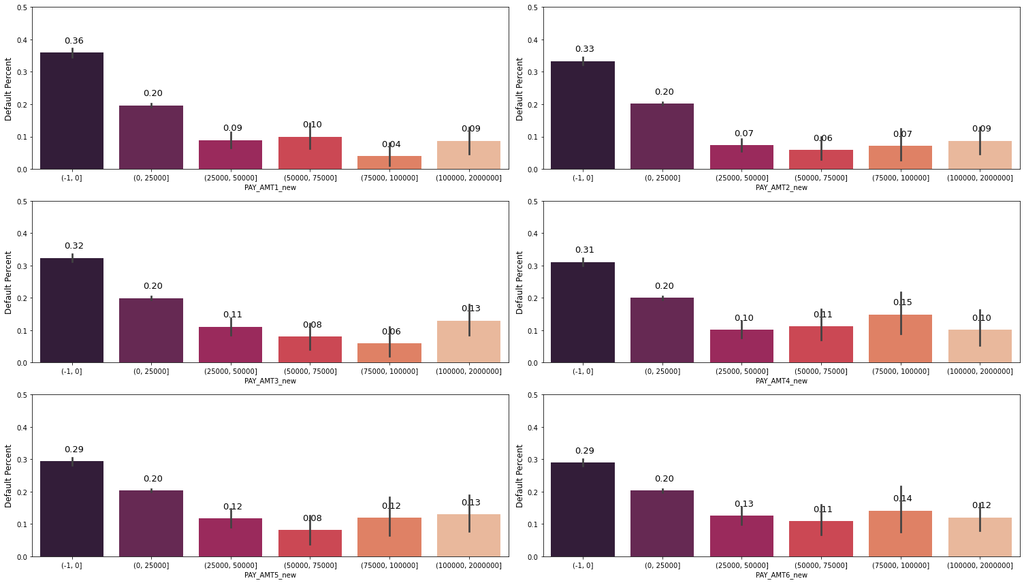

```python
plt.figure(figsize=(21,12))

for i,col in enumerate(pay_amtx_new):
    plt.subplot(3,2,i + 1)
    ax = sns.barplot(x = col, y = "Default", data = df, palette = 'rocket')
    plt.ylabel("Default Percent", fontsize= 12)
    plt.ylim(0,0.5)
    plt.tight_layout()

    for p in ax.patches:
        ax.annotate("%.2f" %(p.get_height()), (p.get_x()+0.3, p.get_height()+0.03),fontsize=13)

plt.show()
```

# MODEL CREATION and EVALUATION

> Based on the Plot Outcomes, Let's try following Model Algorithms
1. Random Forest
2. XG Boost
3. CatBoost
4. SVC - RandomClassifierCV
5. SVC - GridClassifierCV

Also, will considered model creation with both Modified data as well as Direct data

```python
data = df.copy().drop('Default', axis = 1)
data_out = df['Default']
```

```python
data.head()
```

| ID | LIMIT_BAL | SEX | EDUCATION | MARRIAGE | AGE | PAY_1 | PAY_2 | PAY_3 | PAY_4 | PAY_5 | ... | BILL_AMT3_new | BILL_AMT4_new | BILL_AMT5_new | BILL_AMT6_new | PAY_AMT1_new | PAY_AMT2_new | PAY_AMT3_new | PAY_AMT4_new | PAY_AMT5_new | PAY_AMT6_new |
| --- | --- | --- | --- | --- | --- | --- | --- | --- | --- | --- | --- | --- | --- | --- | --- | --- | --- | --- | --- | --- | --- |
| 1 | 20000.0 | 2 | 2 | 1 | 24 | 2 | 2 | -1 | -1 | -2 | ... | (0, 25000] | (-1, 0] | (-1, 0] | (-1, 0] | (-1, 0] | (0, 25000] | (-1, 0] | (-1, 0] | (-1, 0] | (-1, 0] |
| 2 | 120000.0 | 2 | 2 | 2 | 26 | -1 | 2 | 0 | 0 | 0 | ... | (0, 25000] | (0, 25000] | (0, 25000] | (0, 25000] | (-1, 0] | (0, 25000] | (0, 25000] | (0, 25000] | (-1, 0] | (0, 25000] |
| 3 | 90000.0 | 2 | 2 | 2 | 34 | 0 | 0 | 0 | 0 | 0 | ... | (0, 25000] | (0, 25000] | (0, 25000] | (0, 25000] | (0, 25000] | (0, 25000] | (0, 25000] | (0, 25000] | (0, 25000] | (0, 25000] |
| 4 | 50000.0 | 2 | 2 | 1 | 37 | 0 | 0 | 0 | 0 | 0 | ... | (25000, 70000] | (25000, 70000] | (25000, 70000] | (25000, 70000] | (0, 25000] | (0, 25000] | (0, 25000] | (0, 25000] | (0, 25000] | (0, 25000] |
| 5 | 50000.0 | 1 | 2 | 1 | 57 | -1 | 0 | -1 | 0 | 0 | ... | (25000, 70000] | (0, 25000] | (0, 25000] | (0, 25000] | (0, 25000] | (25000, 50000] | (0, 25000] | (0, 25000] | (0, 25000] | (0, 25000] |

5 rows × 43 columns

```python
data.info()
```

```
<class 'pandas.core.frame.DataFrame'>
Int64Index: 30000 entries, 1 to 30000
Data columns (total 43 columns):
 #   Column         Non-Null Count  Dtype
---  ------         --------------  -----
 0   LIMIT_BAL      30000 non-null  float64
 1   SEX            30000 non-null  int64
 2   EDUCATION      30000 non-null  int64
 3   MARRIAGE       30000 non-null  int64
 4   AGE            30000 non-null  int64
 5   PAY_1          30000 non-null  int64
 6   PAY_2          30000 non-null  int64
 7   PAY_3          30000 non-null  int64
 8   PAY_4          30000 non-null  int64
 9   PAY_5          30000 non-null  int64
```

[output cut: 35 more lines]

Hence, we can see that we have the modified columns with "_new" suffix. First lets consider direct data for now

```python
database = data.copy().drop(pay_x_new, axis = 1)
database = database.drop(bill_amtx_feat_new, axis = 1)
database = database.drop(pay_amtx_new, axis = 1)
database = database.drop(['AgeBin', 'Limit_Bal_Bin'], axis = 1)
database
```

| ID | LIMIT_BAL | SEX | EDUCATION | MARRIAGE | AGE | PAY_1 | PAY_2 | PAY_3 | PAY_4 | PAY_5 | ... | BILL_AMT3 | BILL_AMT4 | BILL_AMT5 | BILL_AMT6 | PAY_AMT1 | PAY_AMT2 | PAY_AMT3 | PAY_AMT4 | PAY_AMT5 | PAY_AMT6 |
| --- | --- | --- | --- | --- | --- | --- | --- | --- | --- | --- | --- | --- | --- | --- | --- | --- | --- | --- | --- | --- | --- |
| 1 | 20000.0 | 2 | 2 | 1 | 24 | 2 | 2 | -1 | -1 | -2 | ... | 689.0 | 0.0 | 0.0 | 0.0 | 0.0 | 689.0 | 0.0 | 0.0 | 0.0 | 0.0 |
| 2 | 120000.0 | 2 | 2 | 2 | 26 | -1 | 2 | 0 | 0 | 0 | ... | 2682.0 | 3272.0 | 3455.0 | 3261.0 | 0.0 | 1000.0 | 1000.0 | 1000.0 | 0.0 | 2000.0 |
| 3 | 90000.0 | 2 | 2 | 2 | 34 | 0 | 0 | 0 | 0 | 0 | ... | 13559.0 | 14331.0 | 14948.0 | 15549.0 | 1518.0 | 1500.0 | 1000.0 | 1000.0 | 1000.0 | 5000.0 |
| 4 | 50000.0 | 2 | 2 | 1 | 37 | 0 | 0 | 0 | 0 | 0 | ... | 49291.0 | 28314.0 | 28959.0 | 29547.0 | 2000.0 | 2019.0 | 1200.0 | 1100.0 | 1069.0 | 1000.0 |
| 5 | 50000.0 | 1 | 2 | 1 | 57 | -1 | 0 | -1 | 0 | 0 | ... | 35835.0 | 20940.0 | 19146.0 | 19131.0 | 2000.0 | 36681.0 | 10000.0 | 9000.0 | 689.0 | 679.0 |
| ... | ... | ... | ... | ... | ... | ... | ... | ... | ... | ... | ... | ... | ... | ... | ... | ... | ... | ... | ... | ... | ... |
| 29996 | 220000.0 | 1 | 3 | 1 | 39 | 0 | 0 | 0 | 0 | 0 | ... | 208365.0 | 88004.0 | 31237.0 | 15980.0 | 8500.0 | 20000.0 | 5003.0 | 3047.0 | 5000.0 | 1000.0 |
| 29997 | 150000.0 | 1 | 3 | 2 | 43 | -1 | -1 | -1 | -1 | 0 | ... | 3502.0 | 8979.0 | 5190.0 | 0.0 | 1837.0 | 3526.0 | 8998.0 | 129.0 | 0.0 | 0.0 |
| 29998 | 30000.0 | 1 | 2 | 2 | 37 | 4 | 3 | 2 | -1 | 0 | ... | 2758.0 | 20878.0 | 20582.0 | 19357.0 | 0.0 | 0.0 | 22000.0 | 4200.0 | 2000.0 | 3100.0 |
| 29999 | 80000.0 | 1 | 3 | 1 | 41 | 1 | -1 | 0 | 0 | 0 | ... | 76304.0 | 52774.0 | 11855.0 | 48944.0 | 85900.0 | 3409.0 | 1178.0 | 1926.0 | 52964.0 | 1804.0 |
| 30000 | 50000.0 | 1 | 2 | 1 | 46 | 0 | 0 | 0 | 0 | 0 | ... | 49764.0 | 36535.0 | 32428.0 | 15313.0 | 2078.0 | 1800.0 | 1430.0 | 1000.0 | 1000.0 | 1000.0 |

30000 rows × 23 columns

```python
database.info()
```

```
<class 'pandas.core.frame.DataFrame'>
Int64Index: 30000 entries, 1 to 30000
Data columns (total 23 columns):
 #   Column     Non-Null Count  Dtype
---  ------     --------------  -----
 0   LIMIT_BAL  30000 non-null  float64
 1   SEX        30000 non-null  int64
 2   EDUCATION  30000 non-null  int64
 3   MARRIAGE   30000 non-null  int64
 4   AGE        30000 non-null  int64
 5   PAY_1      30000 non-null  int64
 6   PAY_2      30000 non-null  int64
 7   PAY_3      30000 non-null  int64
 8   PAY_4      30000 non-null  int64
 9   PAY_5      30000 non-null  int64
 10  PAY_6      30000 non-null  int64
 11  BILL_AMT1  30000 non-null  float64
 12  BILL_AMT2  30000 non-null  float64
 13  BILL_AMT3  30000 non-null  float64
 14  BILL_AMT4  30000 non-null  float64
 15  BILL_AMT5  30000 non-null  float64
 16  BILL_AMT6  30000 non-null  float64
 17  PAY_AMT1   30000 non-null  float64
 18  PAY_AMT2   30000 non-null  float64
 19  PAY_AMT3   30000 non-null  float64
 20  PAY_AMT4   30000 non-null  float64
 21  PAY_AMT5   30000 non-null  float64
 22  PAY_AMT6   30000 non-null  float64
dtypes: float64(13), int64(10)
memory usage: 6.7 MB
```

> TEST - TRAIN SPLIT

```python
database_train, database_test, data_out_train, data_out_test = train_test_split(database, data_out, test_size = 0.2, random_state = 42, stratify = data_out)
```

# RANDOM FOREST APPROACH WITHOUT MODIFIED DATA

> Reason for using Random Forest model is to provide a baseline score to compare other models

```python
rf_model = RandomForestClassifier(random_state = 7)

rf_model.fit(database_train, data_out_train)
pred_rf = rf_model.predict(database_test)

print("Test Accuracy: ",metrics.accuracy_score(data_out_test, pred_rf))
```

```
Test Accuracy:  0.8113333333333334
```

> CONFUSION MATRIX

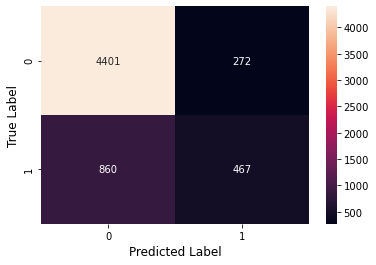

```python
rf_confusion_matrix = metrics.confusion_matrix(data_out_test, pred_rf)
sns.heatmap(rf_confusion_matrix, annot=True, fmt="2g")

plt.xlabel("Predicted Label", fontsize= 12)
plt.ylabel("True Label", fontsize= 12)

plt.show()
```

```python
print(metrics.classification_report(data_out_test, pred_rf, labels = [0, 1]))
```

```
              precision    recall  f1-score   support

           0       0.84      0.94      0.89      4673
           1       0.63      0.35      0.45      1327

    accuracy                           0.81      6000
   macro avg       0.73      0.65      0.67      6000
weighted avg       0.79      0.81      0.79      6000
```

> AREA UNDER CURVE - RECEIEVER CHARACTERISTICS OPERATOR (AUC -ROC)

```
ROC_AUC:  0.7554387782368561
```

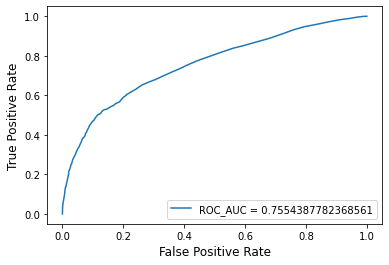

```python
rf_pred_proba = rf_model.predict_proba(database_test)[:,1]

rf_roc_auc = metrics.roc_auc_score(data_out_test, rf_pred_proba)
print('ROC_AUC: ', rf_roc_auc)

rf_fpr, rf_tpr, thresholds = metrics.roc_curve(data_out_test, rf_pred_proba)

plt.plot(rf_fpr,rf_tpr, label = 'ROC_AUC = {}'.format(rf_roc_auc))

plt.xlabel("False Positive Rate", fontsize= 12)
plt.ylabel("True Positive Rate", fontsize= 12)
plt.legend(loc="lower right")

plt.show()
```

# RANDOM FOREST CLASSIFIER WITH MODIFIED DATA

```python
data_new = data.copy().drop(pay_x_new, axis = 1)
data_new = data_new.drop(bill_amtx_feat_new, axis = 1)
data_new = data_new.drop(['AgeBin', 'Limit_Bal_Bin'], axis = 1)

data_new
```

| ID | LIMIT_BAL | SEX | EDUCATION | MARRIAGE | AGE | PAY_1 | PAY_2 | PAY_3 | PAY_4 | PAY_5 | ... | PAY_AMT3 | PAY_AMT4 | PAY_AMT5 | PAY_AMT6 | PAY_AMT1_new | PAY_AMT2_new | PAY_AMT3_new | PAY_AMT4_new | PAY_AMT5_new | PAY_AMT6_new |
| --- | --- | --- | --- | --- | --- | --- | --- | --- | --- | --- | --- | --- | --- | --- | --- | --- | --- | --- | --- | --- | --- |
| 1 | 20000.0 | 2 | 2 | 1 | 24 | 2 | 2 | -1 | -1 | -2 | ... | 0.0 | 0.0 | 0.0 | 0.0 | (-1, 0] | (0, 25000] | (-1, 0] | (-1, 0] | (-1, 0] | (-1, 0] |
| 2 | 120000.0 | 2 | 2 | 2 | 26 | -1 | 2 | 0 | 0 | 0 | ... | 1000.0 | 1000.0 | 0.0 | 2000.0 | (-1, 0] | (0, 25000] | (0, 25000] | (0, 25000] | (-1, 0] | (0, 25000] |
| 3 | 90000.0 | 2 | 2 | 2 | 34 | 0 | 0 | 0 | 0 | 0 | ... | 1000.0 | 1000.0 | 1000.0 | 5000.0 | (0, 25000] | (0, 25000] | (0, 25000] | (0, 25000] | (0, 25000] | (0, 25000] |
| 4 | 50000.0 | 2 | 2 | 1 | 37 | 0 | 0 | 0 | 0 | 0 | ... | 1200.0 | 1100.0 | 1069.0 | 1000.0 | (0, 25000] | (0, 25000] | (0, 25000] | (0, 25000] | (0, 25000] | (0, 25000] |
| 5 | 50000.0 | 1 | 2 | 1 | 57 | -1 | 0 | -1 | 0 | 0 | ... | 10000.0 | 9000.0 | 689.0 | 679.0 | (0, 25000] | (25000, 50000] | (0, 25000] | (0, 25000] | (0, 25000] | (0, 25000] |
| ... | ... | ... | ... | ... | ... | ... | ... | ... | ... | ... | ... | ... | ... | ... | ... | ... | ... | ... | ... | ... | ... |
| 29996 | 220000.0 | 1 | 3 | 1 | 39 | 0 | 0 | 0 | 0 | 0 | ... | 5003.0 | 3047.0 | 5000.0 | 1000.0 | (0, 25000] | (0, 25000] | (0, 25000] | (0, 25000] | (0, 25000] | (0, 25000] |
| 29997 | 150000.0 | 1 | 3 | 2 | 43 | -1 | -1 | -1 | -1 | 0 | ... | 8998.0 | 129.0 | 0.0 | 0.0 | (0, 25000] | (0, 25000] | (0, 25000] | (0, 25000] | (-1, 0] | (-1, 0] |
| 29998 | 30000.0 | 1 | 2 | 2 | 37 | 4 | 3 | 2 | -1 | 0 | ... | 22000.0 | 4200.0 | 2000.0 | 3100.0 | (-1, 0] | (-1, 0] | (0, 25000] | (0, 25000] | (0, 25000] | (0, 25000] |
| 29999 | 80000.0 | 1 | 3 | 1 | 41 | 1 | -1 | 0 | 0 | 0 | ... | 1178.0 | 1926.0 | 52964.0 | 1804.0 | (75000, 100000] | (0, 25000] | (0, 25000] | (0, 25000] | (50000, 75000] | (0, 25000] |
| 30000 | 50000.0 | 1 | 2 | 1 | 46 | 0 | 0 | 0 | 0 | 0 | ... | 1430.0 | 1000.0 | 1000.0 | 1000.0 | (0, 25000] | (0, 25000] | (0, 25000] | (0, 25000] | (0, 25000] | (0, 25000] |

30000 rows × 29 columns

```python
data_new.info()
```

```
<class 'pandas.core.frame.DataFrame'>
Int64Index: 30000 entries, 1 to 30000
Data columns (total 29 columns):
 #   Column        Non-Null Count  Dtype
---  ------        --------------  -----
 0   LIMIT_BAL     30000 non-null  float64
 1   SEX           30000 non-null  int64
 2   EDUCATION     30000 non-null  int64
 3   MARRIAGE      30000 non-null  int64
 4   AGE           30000 non-null  int64
 5   PAY_1         30000 non-null  int64
 6   PAY_2         30000 non-null  int64
 7   PAY_3         30000 non-null  int64
 8   PAY_4         30000 non-null  int64
 9   PAY_5         30000 non-null  int64
```

[output cut: 21 more lines]

```python
le = LabelEncoder()

for col in pay_amtx_new:
    data_new[col] = le.fit_transform(data_new[col])
```

```python
data_new.info()
```

```
<class 'pandas.core.frame.DataFrame'>
Int64Index: 30000 entries, 1 to 30000
Data columns (total 29 columns):
 #   Column        Non-Null Count  Dtype
---  ------        --------------  -----
 0   LIMIT_BAL     30000 non-null  float64
 1   SEX           30000 non-null  int64
 2   EDUCATION     30000 non-null  int64
 3   MARRIAGE      30000 non-null  int64
 4   AGE           30000 non-null  int64
 5   PAY_1         30000 non-null  int64
 6   PAY_2         30000 non-null  int64
 7   PAY_3         30000 non-null  int64
 8   PAY_4         30000 non-null  int64
 9   PAY_5         30000 non-null  int64
```

[output cut: 21 more lines]

```python
data_new_train, data_new_test, data_out_train, data_out_test = train_test_split(data_new, data_out, test_size = 0.2, random_state = 7, stratify = data_out)
```

```python
rf_model_new = RandomForestClassifier(random_state = 7)

rf_model_new.fit(data_new_train, data_out_train)
pred_rf_new = rf_model_new.predict(data_new_test)

print("Test Accuracy: ",metrics.accuracy_score(data_out_test, pred_rf_new))
```

```
Test Accuracy:  0.8231666666666667
```

> CONFUSION MATRIX

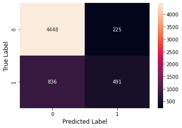

```python
rf_confusion_matrix = metrics.confusion_matrix(data_out_test, pred_rf_new)
sns.heatmap(rf_confusion_matrix, annot=True, fmt="2g")

plt.xlabel("Predicted Label", fontsize= 12)
plt.ylabel("True Label", fontsize= 12)

plt.show()
```

```
ROC_AUC:  0.7830107895877987
```

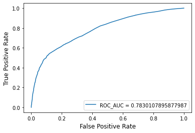

```python
rf_pred_proba_new = rf_model_new.predict_proba(data_new_test)[:,1]

rf_roc_auc_new = metrics.roc_auc_score(data_out_test, rf_pred_proba_new)
print('ROC_AUC: ', rf_roc_auc_new)

rf_new_fpr, rf_new_tpr, thresholds_new = metrics.roc_curve(data_out_test, rf_pred_proba_new)

plt.plot(rf_new_fpr,rf_new_tpr, label = 'ROC_AUC = {}'.format(rf_roc_auc_new))

plt.xlabel("False Positive Rate", fontsize= 12)
plt.ylabel("True Positive Rate", fontsize= 12)
plt.legend(loc="lower right")

plt.show()
```

Hence, AUC -ROC has been increased by 3% hence, data modification made is under right criteria.

# XG BOOST WITHOUT MODIFIED DATA

```python
data_xg = database.copy()
data_xg_out = data_out.copy()
```

```python
from sklearn.model_selection import train_test_split
data_xg_train, data_xg_test, data_xg_out_train, data_xg_out_test = train_test_split(data_xg, data_xg_out, test_size = 0.25)
```

```python
param_grid = {
        'gamma': [0.5, 1, 5],   # regularization parameter
        'subsample': [0.3,  0.7, 1.0], # % of rows taken to build each tree
        'colsample_bytree': [0.6, 0.8, 1.0], # number of columns used by each tree
        'max_depth': [ 5, 6] # depth of each tree
        }
```

```python
import xgboost as xgb
xgb_model = xgb.XGBClassifier(learning_rate=0.01, n_estimators=100, eval_metric='logloss', use_label_encoder=False)
from sklearn.model_selection import GridSearchCV

grid = GridSearchCV(xgb_model, param_grid, refit = True, verbose = 4)
grid.fit(data_xg_train, data_xg_out_train)
```

```
Fitting 5 folds for each of 54 candidates, totalling 270 fits
[CV] colsample_bytree=0.6, gamma=0.5, max_depth=5, subsample=0.3 .....
```

```
[Parallel(n_jobs=1)]: Using backend SequentialBackend with 1 concurrent workers.
```

```
[CV]  colsample_bytree=0.6, gamma=0.5, max_depth=5, subsample=0.3, score=0.814, total=   2.6s
[CV] colsample_bytree=0.6, gamma=0.5, max_depth=5, subsample=0.3 .....
```

```
[Parallel(n_jobs=1)]: Done   1 out of   1 | elapsed:    2.5s remaining:    0.0s
```

```
[CV]  colsample_bytree=0.6, gamma=0.5, max_depth=5, subsample=0.3, score=0.827, total=   1.1s
[CV] colsample_bytree=0.6, gamma=0.5, max_depth=5, subsample=0.3 .....
```

```
[Parallel(n_jobs=1)]: Done   2 out of   2 | elapsed:    3.6s remaining:    0.0s
```

```
[CV]  colsample_bytree=0.6, gamma=0.5, max_depth=5, subsample=0.3, score=0.818, total=   1.0s
[CV] colsample_bytree=0.6, gamma=0.5, max_depth=5, subsample=0.3 .....
```

```
[Parallel(n_jobs=1)]: Done   3 out of   3 | elapsed:    4.6s remaining:    0.0s
```

[output not shown]

[output cut: 478 more lines]

[output not shown]

```
[Parallel(n_jobs=1)]: Done 270 out of 270 | elapsed:  5.0min finished
```

```
GridSearchCV(estimator=XGBClassifier(base_score=None, booster=None,
                                     colsample_bylevel=None,
                                     colsample_bynode=None,
                                     colsample_bytree=None,
                                     eval_metric='logloss', gamma=None,
                                     gpu_id=None, importance_type='gain',
                                     interaction_constraints=None,
                                     learning_rate=0.01, max_delta_step=None,
                                     max_depth=None, min_child_weight=None,
                                     missing=nan, monotone_constraints=None,
                                     n_estimators=100, n_jobs=None,
                                     num_parallel_tree=None, random_state=None,
                                     reg_alpha=None, reg_lambda=None,
                                     scale_pos_weight=None, subsample=None,
                                     tree_method=None, use_label_encoder=False,
                                     validate_parameters=None, verbosity=None),
             param_grid={'colsample_bytree': [0.6, 0.8, 1.0],
                         'gamma': [0.5, 1, 5], 'max_depth': [5, 6],
                         'subsample': [0.3, 0.7, 1.0]},
             verbose=4)
```

```python
data_out_xg_prob=grid.predict_proba(data_xg_test)
data_out_xg_pred = grid.predict(data_xg_test)
```

```
Test Accuracy:  0.8228
```

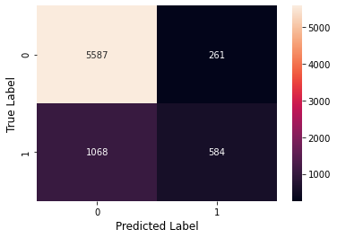

```python
rf_confusion_matrix = metrics.confusion_matrix(data_xg_out_test, data_out_xg_pred)
sns.heatmap(rf_confusion_matrix, annot=True, fmt="2g")

plt.xlabel("Predicted Label", fontsize= 12)
plt.ylabel("True Label", fontsize= 12)
print("Test Accuracy: ",metrics.accuracy_score(data_xg_out_test, data_out_xg_pred))
plt.show()
```

Accuracy seems to be increased but, the True Positive and True Negative proportion is in same ratio as of the Random Forest Model Metrics

# CATBOOST WITHOUT MODIFIED DATA

```python
X = df.copy().drop('Default', axis = 1)
Y = df['Default']
```

```python
X_base = X.copy().drop(pay_x_new, axis = 1)
X_base = X_base.drop(bill_amtx_feat_new, axis = 1)
X_base = X_base.drop(pay_amtx_new, axis = 1)
X_base = X_base.drop(['AgeBin', 'Limit_Bal_Bin'], axis = 1)
X_base
```

| ID | LIMIT_BAL | SEX | EDUCATION | MARRIAGE | AGE | PAY_1 | PAY_2 | PAY_3 | PAY_4 | PAY_5 | ... | BILL_AMT3 | BILL_AMT4 | BILL_AMT5 | BILL_AMT6 | PAY_AMT1 | PAY_AMT2 | PAY_AMT3 | PAY_AMT4 | PAY_AMT5 | PAY_AMT6 |
| --- | --- | --- | --- | --- | --- | --- | --- | --- | --- | --- | --- | --- | --- | --- | --- | --- | --- | --- | --- | --- | --- |
| 1 | 20000.0 | 2 | 2 | 1 | 24 | 2 | 2 | -1 | -1 | -2 | ... | 689.0 | 0.0 | 0.0 | 0.0 | 0.0 | 689.0 | 0.0 | 0.0 | 0.0 | 0.0 |
| 2 | 120000.0 | 2 | 2 | 2 | 26 | -1 | 2 | 0 | 0 | 0 | ... | 2682.0 | 3272.0 | 3455.0 | 3261.0 | 0.0 | 1000.0 | 1000.0 | 1000.0 | 0.0 | 2000.0 |
| 3 | 90000.0 | 2 | 2 | 2 | 34 | 0 | 0 | 0 | 0 | 0 | ... | 13559.0 | 14331.0 | 14948.0 | 15549.0 | 1518.0 | 1500.0 | 1000.0 | 1000.0 | 1000.0 | 5000.0 |
| 4 | 50000.0 | 2 | 2 | 1 | 37 | 0 | 0 | 0 | 0 | 0 | ... | 49291.0 | 28314.0 | 28959.0 | 29547.0 | 2000.0 | 2019.0 | 1200.0 | 1100.0 | 1069.0 | 1000.0 |
| 5 | 50000.0 | 1 | 2 | 1 | 57 | -1 | 0 | -1 | 0 | 0 | ... | 35835.0 | 20940.0 | 19146.0 | 19131.0 | 2000.0 | 36681.0 | 10000.0 | 9000.0 | 689.0 | 679.0 |
| ... | ... | ... | ... | ... | ... | ... | ... | ... | ... | ... | ... | ... | ... | ... | ... | ... | ... | ... | ... | ... | ... |
| 29996 | 220000.0 | 1 | 3 | 1 | 39 | 0 | 0 | 0 | 0 | 0 | ... | 208365.0 | 88004.0 | 31237.0 | 15980.0 | 8500.0 | 20000.0 | 5003.0 | 3047.0 | 5000.0 | 1000.0 |
| 29997 | 150000.0 | 1 | 3 | 2 | 43 | -1 | -1 | -1 | -1 | 0 | ... | 3502.0 | 8979.0 | 5190.0 | 0.0 | 1837.0 | 3526.0 | 8998.0 | 129.0 | 0.0 | 0.0 |
| 29998 | 30000.0 | 1 | 2 | 2 | 37 | 4 | 3 | 2 | -1 | 0 | ... | 2758.0 | 20878.0 | 20582.0 | 19357.0 | 0.0 | 0.0 | 22000.0 | 4200.0 | 2000.0 | 3100.0 |
| 29999 | 80000.0 | 1 | 3 | 1 | 41 | 1 | -1 | 0 | 0 | 0 | ... | 76304.0 | 52774.0 | 11855.0 | 48944.0 | 85900.0 | 3409.0 | 1178.0 | 1926.0 | 52964.0 | 1804.0 |
| 30000 | 50000.0 | 1 | 2 | 1 | 46 | 0 | 0 | 0 | 0 | 0 | ... | 49764.0 | 36535.0 | 32428.0 | 15313.0 | 2078.0 | 1800.0 | 1430.0 | 1000.0 | 1000.0 | 1000.0 |

30000 rows × 23 columns

```python
X_base_train, X_base_test, Y_train, Y_test = train_test_split(X_base, Y, test_size = 0.2, random_state = 42, stratify = Y)
```

```python
categorical_ft_base = ['SEX', 'EDUCATION', 'MARRIAGE']

cat_model = CatBoostClassifier (random_state = 42, eval_metric = 'AUC')
cat_model.fit(X_base_train, Y_train, early_stopping_rounds = 100, eval_set = [(X_base_test,Y_test)], cat_features = categorical_ft_base)
pred_cat = cat_model.predict(X_base_test)
```

[output not shown]

[output cut: 314 more lines]

```
353:	test: 0.7793405	best: 0.7810773 (261)	total: 36.1s	remaining: 1m 5s
354:	test: 0.7792952	best: 0.7810773 (261)	total: 36.2s	remaining: 1m 5s
355:	test: 0.7792786	best: 0.7810773 (261)	total: 36.3s	remaining: 1m 5s
356:	test: 0.7792765	best: 0.7810773 (261)	total: 36.4s	remaining: 1m 5s
357:	test: 0.7793268	best: 0.7810773 (261)	total: 36.5s	remaining: 1m 5s
358:	test: 0.7794226	best: 0.7810773 (261)	total: 36.6s	remaining: 1m 5s
359:	test: 0.7794275	best: 0.7810773 (261)	total: 36.7s	remaining: 1m 5s
360:	test: 0.7793794	best: 0.7810773 (261)	total: 36.8s	remaining: 1m 5s
361:	test: 0.7791773	best: 0.7810773 (261)	total: 36.9s	remaining: 1m 4s
Stopped by overfitting detector  (100 iterations wait)

bestTest = 0.7810773333
bestIteration = 261

Shrink model to first 262 iterations.
```

```python
print("Test Accuracy: ",metrics.accuracy_score(Y_test, pred_cat))
```

```
Test Accuracy:  0.818
```

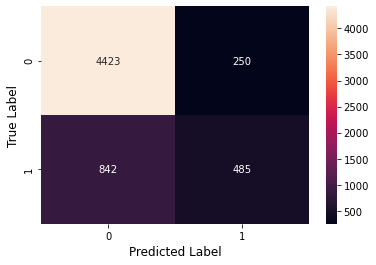

```python
cat_confusion_matrix = metrics.confusion_matrix(Y_test, pred_cat)
sns.heatmap(cat_confusion_matrix, annot=True, fmt="d")

plt.xlabel("Predicted Label", fontsize= 12)
plt.ylabel("True Label", fontsize= 12)

plt.show()
```

```python
print(metrics.classification_report(Y_test, pred_cat, labels = [0, 1]))
```

```
              precision    recall  f1-score   support

           0       0.84      0.95      0.89      4673
           1       0.66      0.37      0.47      1327

    accuracy                           0.82      6000
   macro avg       0.75      0.66      0.68      6000
weighted avg       0.80      0.82      0.80      6000
```

```
ROC_AUC:  0.7810773332542074
```

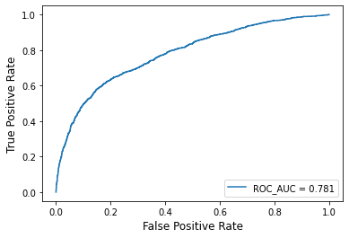

```python
cat_pred_proba = cat_model.predict_proba(X_base_test)[:,1]

cat_roc_auc = metrics.roc_auc_score(Y_test, cat_pred_proba)
print('ROC_AUC: ', cat_roc_auc)

cat_fpr, cat_tpr, thresholds = metrics.roc_curve(Y_test, cat_pred_proba)

plt.plot(cat_fpr,cat_tpr, label = 'ROC_AUC = %0.3f' % cat_roc_auc)

plt.xlabel("False Positive Rate", fontsize= 12)
plt.ylabel("True Positive Rate", fontsize= 12)
plt.legend(loc="lower right")

plt.show()
```

> CATBOOST WITH MODIFIED DATA

```python
X_new = X.copy().drop(pay_x_new, axis = 1)
X_new = X_new.drop(bill_amtx_feat_new, axis = 1)
X_new = X_new.drop(['AgeBin', 'Limit_Bal_Bin'], axis = 1)

X_new
```

| ID | LIMIT_BAL | SEX | EDUCATION | MARRIAGE | AGE | PAY_1 | PAY_2 | PAY_3 | PAY_4 | PAY_5 | ... | PAY_AMT3 | PAY_AMT4 | PAY_AMT5 | PAY_AMT6 | PAY_AMT1_new | PAY_AMT2_new | PAY_AMT3_new | PAY_AMT4_new | PAY_AMT5_new | PAY_AMT6_new |
| --- | --- | --- | --- | --- | --- | --- | --- | --- | --- | --- | --- | --- | --- | --- | --- | --- | --- | --- | --- | --- | --- |
| 1 | 20000.0 | 2 | 2 | 1 | 24 | 2 | 2 | -1 | -1 | -2 | ... | 0.0 | 0.0 | 0.0 | 0.0 | (-1, 0] | (0, 25000] | (-1, 0] | (-1, 0] | (-1, 0] | (-1, 0] |
| 2 | 120000.0 | 2 | 2 | 2 | 26 | -1 | 2 | 0 | 0 | 0 | ... | 1000.0 | 1000.0 | 0.0 | 2000.0 | (-1, 0] | (0, 25000] | (0, 25000] | (0, 25000] | (-1, 0] | (0, 25000] |
| 3 | 90000.0 | 2 | 2 | 2 | 34 | 0 | 0 | 0 | 0 | 0 | ... | 1000.0 | 1000.0 | 1000.0 | 5000.0 | (0, 25000] | (0, 25000] | (0, 25000] | (0, 25000] | (0, 25000] | (0, 25000] |
| 4 | 50000.0 | 2 | 2 | 1 | 37 | 0 | 0 | 0 | 0 | 0 | ... | 1200.0 | 1100.0 | 1069.0 | 1000.0 | (0, 25000] | (0, 25000] | (0, 25000] | (0, 25000] | (0, 25000] | (0, 25000] |
| 5 | 50000.0 | 1 | 2 | 1 | 57 | -1 | 0 | -1 | 0 | 0 | ... | 10000.0 | 9000.0 | 689.0 | 679.0 | (0, 25000] | (25000, 50000] | (0, 25000] | (0, 25000] | (0, 25000] | (0, 25000] |
| ... | ... | ... | ... | ... | ... | ... | ... | ... | ... | ... | ... | ... | ... | ... | ... | ... | ... | ... | ... | ... | ... |
| 29996 | 220000.0 | 1 | 3 | 1 | 39 | 0 | 0 | 0 | 0 | 0 | ... | 5003.0 | 3047.0 | 5000.0 | 1000.0 | (0, 25000] | (0, 25000] | (0, 25000] | (0, 25000] | (0, 25000] | (0, 25000] |
| 29997 | 150000.0 | 1 | 3 | 2 | 43 | -1 | -1 | -1 | -1 | 0 | ... | 8998.0 | 129.0 | 0.0 | 0.0 | (0, 25000] | (0, 25000] | (0, 25000] | (0, 25000] | (-1, 0] | (-1, 0] |
| 29998 | 30000.0 | 1 | 2 | 2 | 37 | 4 | 3 | 2 | -1 | 0 | ... | 22000.0 | 4200.0 | 2000.0 | 3100.0 | (-1, 0] | (-1, 0] | (0, 25000] | (0, 25000] | (0, 25000] | (0, 25000] |
| 29999 | 80000.0 | 1 | 3 | 1 | 41 | 1 | -1 | 0 | 0 | 0 | ... | 1178.0 | 1926.0 | 52964.0 | 1804.0 | (75000, 100000] | (0, 25000] | (0, 25000] | (0, 25000] | (50000, 75000] | (0, 25000] |
| 30000 | 50000.0 | 1 | 2 | 1 | 46 | 0 | 0 | 0 | 0 | 0 | ... | 1430.0 | 1000.0 | 1000.0 | 1000.0 | (0, 25000] | (0, 25000] | (0, 25000] | (0, 25000] | (0, 25000] | (0, 25000] |

30000 rows × 29 columns

```python
X_new.info()
```

```
<class 'pandas.core.frame.DataFrame'>
Int64Index: 30000 entries, 1 to 30000
Data columns (total 29 columns):
 #   Column        Non-Null Count  Dtype
---  ------        --------------  -----
 0   LIMIT_BAL     30000 non-null  float64
 1   SEX           30000 non-null  int64
 2   EDUCATION     30000 non-null  int64
 3   MARRIAGE      30000 non-null  int64
 4   AGE           30000 non-null  int64
 5   PAY_1         30000 non-null  int64
 6   PAY_2         30000 non-null  int64
 7   PAY_3         30000 non-null  int64
 8   PAY_4         30000 non-null  int64
 9   PAY_5         30000 non-null  int64
```

[output cut: 21 more lines]

```python
le = LabelEncoder()

for col in pay_amtx_new:
    X_new[col] = le.fit_transform(X_new[col])
```

```python
X_new_train, X_new_test, Y_train, Y_test = train_test_split(X_new, Y, test_size = 0.2, random_state = 42, stratify = Y)
```

```python
categorical_ft_new = ['SEX', 'EDUCATION', 'MARRIAGE'
                      , 'PAY_AMT1_new', 'PAY_AMT2_new', 'PAY_AMT3_new', 'PAY_AMT4_new', 'PAY_AMT5_new', 'PAY_AMT6_new']

print(categorical_ft_new)

cat_model_new = CatBoostClassifier (random_state = 42, eval_metric = 'AUC')
cat_model_new.fit(X_new_train, Y_train, early_stopping_rounds = 100, eval_set = [(X_new_test,Y_test)], cat_features = categorical_ft_new)
pred_cat_new = cat_model_new.predict(X_new_test)
```

[output not shown]

[output cut: 310 more lines]

```
348:	test: 0.7801738	best: 0.7814702 (256)	total: 39.3s	remaining: 1m 13s
349:	test: 0.7801776	best: 0.7814702 (256)	total: 39.4s	remaining: 1m 13s
350:	test: 0.7800954	best: 0.7814702 (256)	total: 39.5s	remaining: 1m 12s
351:	test: 0.7799807	best: 0.7814702 (256)	total: 39.6s	remaining: 1m 12s
352:	test: 0.7800135	best: 0.7814702 (256)	total: 39.7s	remaining: 1m 12s
353:	test: 0.7800428	best: 0.7814702 (256)	total: 39.8s	remaining: 1m 12s
354:	test: 0.7799674	best: 0.7814702 (256)	total: 39.9s	remaining: 1m 12s
355:	test: 0.7799462	best: 0.7814702 (256)	total: 40s	remaining: 1m 12s
356:	test: 0.7801225	best: 0.7814702 (256)	total: 40.1s	remaining: 1m 12s
Stopped by overfitting detector  (100 iterations wait)

bestTest = 0.7814702493
bestIteration = 256

Shrink model to first 257 iterations.
```

```python
print("Test Accuracy: ",metrics.accuracy_score(Y_test, pred_cat_new))
```

```
Test Accuracy:  0.8195
```

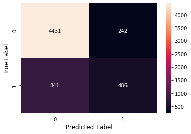

```python
cat_new_confusion_matrix = metrics.confusion_matrix(Y_test, pred_cat_new)
sns.heatmap(cat_new_confusion_matrix, annot=True, fmt="d")

plt.xlabel("Predicted Label", fontsize= 12)
plt.ylabel("True Label", fontsize= 12)

plt.show()
```

Support Vector Classifier - RandomizedSearchCV

```python
from sklearn.svm import SVC
```

```python
param_grid = {'C': [0.1, 1, 10, 100, 1000],
              'gamma': [1, 0.1, 0.01, 0.001, 0.0001],
              'kernel': ['rbf']}
```

```python
SVM_Model = SVC(gamma='auto')
```

```python
from sklearn.model_selection import RandomizedSearchCV
random_Grid = RandomizedSearchCV (estimator = SVM_Model, param_distributions = param_grid, cv = 3, verbose=2, n_jobs = 4)
```

```python
y = df['Default']

#Load X Variables into a Pandas Dataframe with columns
X = X_new.copy().drop(['PAY_AMT1_new', 'PAY_AMT2_new', 'PAY_AMT3_new', 'PAY_AMT4_new', 'PAY_AMT5_new', 'PAY_AMT6_new'], axis = 1)
```

```python
X_train, X_test, y_train, y_test = train_test_split(X, y, test_size = 0.2, random_state = 42, stratify = y)
```

```python
random_Grid.fit(X_train,y_train)
```

```
Fitting 3 folds for each of 10 candidates, totalling 30 fits
```

```
[Parallel(n_jobs=4)]: Using backend LokyBackend with 4 concurrent workers.
[Parallel(n_jobs=4)]: Done  30 out of  30 | elapsed: 29.3min finished
```

```
RandomizedSearchCV(cv=3, estimator=SVC(gamma='auto'), n_jobs=4,
                   param_distributions={'C': [0.1, 1, 10, 100, 1000],
                                        'gamma': [1, 0.1, 0.01, 0.001, 0.0001],
                                        'kernel': ['rbf']},
                   verbose=2)
```

```python
y_pred = random_Grid.predict(X_test)
```

```python
print("Test Accuracy: ",metrics.accuracy_score(y_test, y_pred))
```

```
Test Accuracy:  0.7803333333333333
```

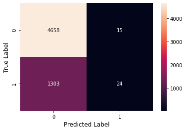

```python
grid_confusion_matrix = metrics.confusion_matrix(y_test, y_pred)
sns.heatmap(grid_confusion_matrix, annot=True, fmt="d")

plt.xlabel("Predicted Label", fontsize= 12)
plt.ylabel("True Label", fontsize= 12)

plt.show()
```

SVC : Grid SearchCV

```python
from sklearn.model_selection import GridSearchCV
Grid_Search = GridSearchCV (estimator = SVM_Model, param_grid = param_grid, cv = 3, verbose=2, n_jobs = 4)
```

```python
Grid_Search.fit(X_train,Y_train)
```

```
Fitting 3 folds for each of 25 candidates, totalling 75 fits
```

```
[Parallel(n_jobs=4)]: Using backend LokyBackend with 4 concurrent workers.
[Parallel(n_jobs=4)]: Done  33 tasks      | elapsed: 19.7min
[Parallel(n_jobs=4)]: Done  75 out of  75 | elapsed: 53.2min finished
```

```
GridSearchCV(cv=3, estimator=SVC(gamma='auto'), n_jobs=4,
             param_grid={'C': [0.1, 1, 10, 100, 1000],
                         'gamma': [1, 0.1, 0.01, 0.001, 0.0001],
                         'kernel': ['rbf']},
             verbose=2)
```

```python
y_pred_new = Grid_Search.predict(X_test)
```

```python
print("Test Accuracy: ",metrics.accuracy_score(y_test, y_pred_new))
```

```
Test Accuracy:  0.7803333333333333
```

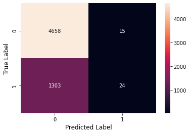

```python
grid_confusion_matrix_1 = metrics.confusion_matrix(y_test, y_pred_new)
sns.heatmap(grid_confusion_matrix_1, annot=True, fmt="d")

plt.xlabel("Predicted Label", fontsize= 12)
plt.ylabel("True Label", fontsize= 12)

plt.show()
```

```python
import pickle

Pkl_Filename = "rf.pkl"

with open(Pkl_Filename, 'wb') as file:
    pickle.dump(rf_model, file)
```

```python
Pkl_Filename = "rf_new.pkl"

with open(Pkl_Filename, 'wb') as file:
    pickle.dump(rf_model_new, file)
```

```python
Pkl_Filename = "xgb.pkl"

with open(Pkl_Filename, 'wb') as file:
    pickle.dump(xgb_model, file)
```

```python
Pkl_Filename = "cat.pkl"

with open(Pkl_Filename, 'wb') as file:
    pickle.dump(cat_model, file)
```

```python
Pkl_Filename = "cat_new.pkl"

with open(Pkl_Filename, 'wb') as file:
    pickle.dump(cat_model_new, file)
```

```python
Pkl_Filename = "rGrid.pkl"

with open(Pkl_Filename, 'wb') as file:
    pickle.dump(random_Grid, file)
```

```python
Pkl_Filename = "gSearch.pkl"

with open(Pkl_Filename, 'wb') as file:
    pickle.dump(Grid_Search, file)
```